# Water, Sanitation, and Hygiene Inequalities among Women in Tanzania

Evidence from the 2015–16 Tanzania Demographic and Health Survey and Malaria Indicator Survey

Fahad Al-Mohammed

29 July 2026

# 1 Report Overview

> **Key message:** This report uses the Tanzania 2015–16 DHS-MIS Women’s Individual Recode data to examine whether household water and sanitation conditions differ across place of residence, wealth, and education.

This report combines narrative text, reproducible R analysis, inline results, four interpreted figures, and a formatted summary table. The analysis is organised from background and methods through findings, discussion, limitations, and conclusion so that a non-technical reader can follow the main public-health story.

# 2 Introduction

Water, sanitation, and hygiene (WASH) are essential components of public health and household infection prevention. Reliable access to safe drinking water supports drinking, cooking, cleaning, and personal hygiene, while adequate sanitation helps reduce contact with human waste and environmental contamination. When households lack reliable water or sanitation services, the health consequences can extend beyond inconvenience. Poor WASH conditions can increase opportunities for infectious disease transmission and may place additional time and physical burdens on household members.

Women are particularly important in WASH research because they frequently contribute substantially to household water management, food preparation, childcare, and cleaning. Where drinking water is not available on the household premises, collecting it may require repeated trips and significant travel time. The burden of water collection can therefore affect time available for education, employment, family care, and rest. Sanitation conditions are also relevant to privacy, dignity, safety, and the prevention of faecal contamination.

This project examines WASH inequalities among women in the **United Republic of Tanzania** using the **2015–16 Tanzania Demographic and Health Survey and Malaria Indicator Survey (TDHS-MIS)**. The analysis uses the Women’s Individual Recode dataset, `TZIR7BFL.DTA`, provided for the course. The dataset contains **13,266 interviewed women** and includes demographic characteristics together with household water and sanitation information.

The main variable of interest is **source of drinking water (`v113`)**, which is included in the course list of biosecurity-relevant DHS variables. The project also examines **time to obtain drinking water (`v115`)**, **type of toilet facility (`v116`)**, and **whether toilet facilities are shared with other households (`v160`)**. These WASH measures are compared across urban and rural residence, household wealth, and women’s educational level.

The central research question is:

> **How do household drinking-water and sanitation conditions differ across socioeconomic groups among women in Tanzania?**

The purpose is descriptive rather than causal. Differences between groups are interpreted as patterns of inequality and not as proof that residence, wealth, or education directly causes a particular WASH condition.

# 3 Country and Survey Context

The United Republic of Tanzania is located in East Africa and includes mainland Tanzania and Zanzibar. The country contains large urban centres, smaller towns, agricultural communities, and geographically remote rural areas. This diversity makes Tanzania a useful setting for investigating inequalities in household infrastructure.

Urban and rural households may have different access to piped water, wells, boreholes, surface water, and sanitation facilities. Wealth can also influence a household’s ability to access or improve infrastructure. Educational level is another useful socioeconomic characteristic because it may be associated with income, residence, employment, and living conditions.

The 2015–16 TDHS-MIS is suitable for this analysis because the Women’s Individual Recode dataset combines individual characteristics with household WASH measures. This allows water and sanitation outcomes to be compared across several sociodemographic groups within one dataset.

# 4 Aim and Research Questions

## 4.1 Aim

The aim of this project is to describe **inequalities in household water and sanitation conditions among women in Tanzania**.

## 4.2 Research Questions

1. What are the major drinking-water sources reported by women in Tanzania?
2. How do drinking-water sources differ between urban and rural areas?
3. Does water-collection time differ across household wealth groups?
4. How do sanitation facility types vary across household wealth groups?
5. Does toilet sharing differ according to women’s educational level?
6. What are the main urban-rural differences across selected WASH indicators?

## 4.3 Variables Used

| DHS variable | Meaning | Role in this project |
| --- | --- | --- |
| `v012` | Respondent’s current age | Demographic characteristic |
| `v024` | Region | Geographic characteristic |
| `v025` | Type of place of residence | Urban/rural comparison |
| `v106` | Highest educational level | Socioeconomic comparison |
| `v113` | Source of drinking water | Main biosecurity/WASH variable |
| `v115` | Time to get to water source | WASH accessibility |
| `v116` | Type of toilet facility | Sanitation outcome |
| `v160` | Toilet facilities shared with other households | Sanitation outcome |
| `v190` | Wealth index | Socioeconomic comparison |

The imported Stata file contains DHS labelled variables. These labels are useful because they preserve the meaning of numeric category codes. However, labelled variables can be inconvenient for plotting and grouping, so the categorical variables are converted to ordinary R factors .

The percentages in this report are simple descriptive percentages from the course dataset. The complete DHS complex-survey design is not applied, so small differences from official DHS estimates are expected.

# 5 Findings

## 5.1 1. Drinking-Water Sources by Residence

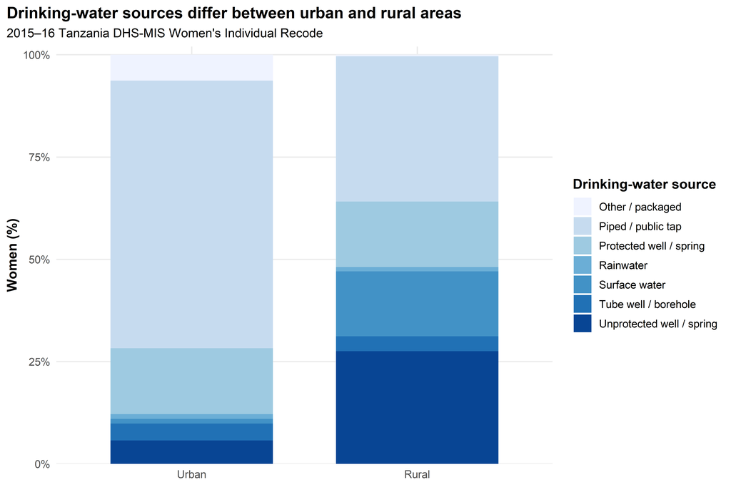

**Interpretation.** Figure 1 shows a clear difference in the composition of household drinking-water sources between urban and rural women. The largest category in urban areas is **Piped / public tap**, accounting for approximately **65.4%** of urban women with a valid water-source response. In rural areas, the largest category is **Piped / public tap**, representing approximately **35.5%**. These differences show why national averages alone may hide important geographic inequalities in water infrastructure and household exposure conditions.

## 5.2 2. Water-Collection Time by Household Wealth

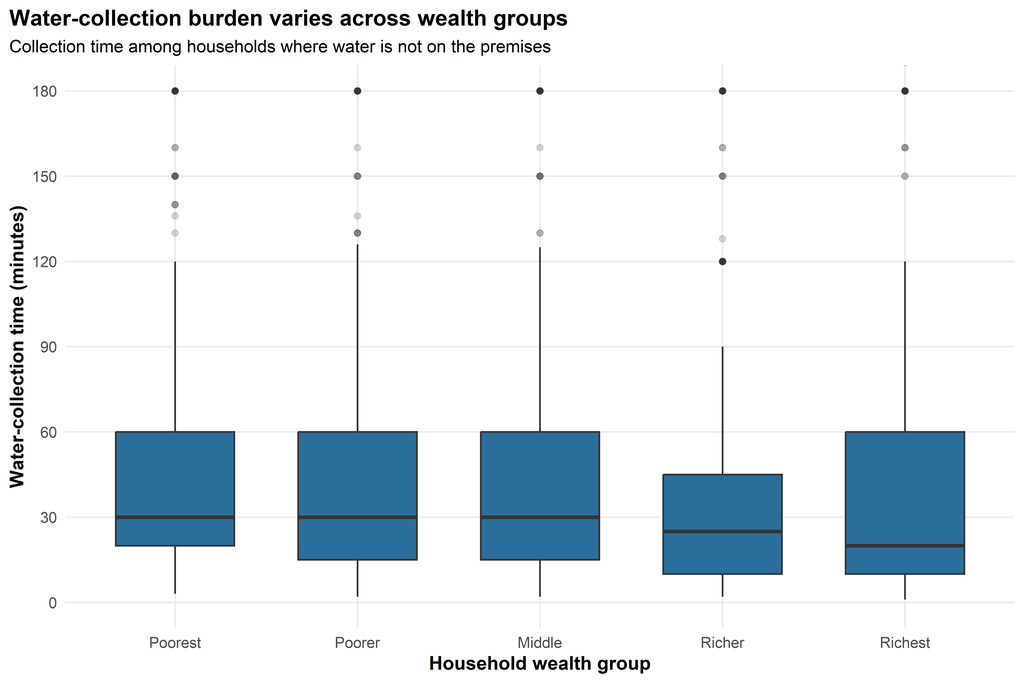

**Interpretation.** Figure 2 demonstrates variation in water-collection burden across household wealth groups. The **Poorest** group has the highest median reported collection time at approximately **30 minutes**, while the **Richest** group has the lowest median at approximately **20 minutes**. Long collection times can represent an important household burden because time spent obtaining water may reduce time available for education, employment, childcare, and other activities.

## 5.3 3. Sanitation Facility Type by Household Wealth

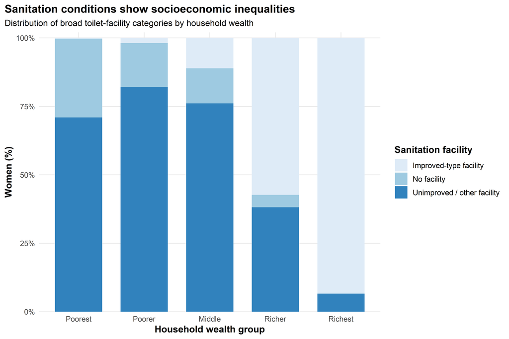

**Interpretation.** Figure 3 shows a socioeconomic gradient in sanitation conditions. The highest percentage of women living in households with **no toilet facility** is found in the **Poorest** group at approximately **28.8%**, compared with approximately **0.1%** in the **Richest** group. This pattern suggests that sanitation disadvantages are concentrated more strongly among some socioeconomic groups, which is relevant to household infection prevention and environmental health.

## 5.4 4. Shared Toilet Facilities by Education

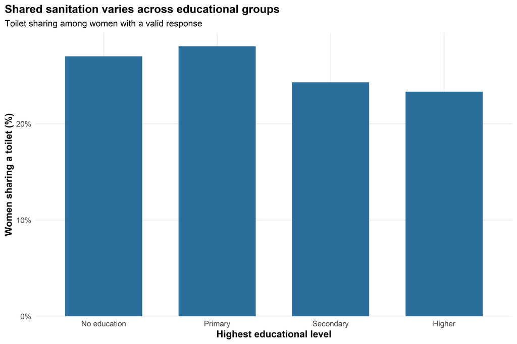

**Interpretation.** Toilet sharing is highest among women in the **Primary** group at approximately **28%**, while the lowest percentage is observed among women in the **Higher** group at approximately **23.3%**. A shared toilet is not automatically unsafe; however, sharing can increase crowding and reduce the degree of control that one household has over cleaning and maintenance. It is therefore useful as an additional dimension of sanitation access.

# 6 WASH Summary Table

The following table compares selected WASH indicators between urban and rural women.

Selected WASH Indicators by Residence

2015–16 Tanzania DHS-MIS Women's Individual Recode

| WASH indicator | Urban (%) | Rural (%) |
| --- | --- | --- |
| Improved-type sanitation facility | 76.6 | 22.7 |
| No toilet facility / bush / field | 1.6 | 14.9 |
| Toilet shared with other households | 38.6 | 20.7 |
| Unprotected well/spring or surface water | 6.9 | 43.4 |
| Water source on household premises | 61.5 | 18.1 |

Source: TZIR7BFL.DTA. Percentages are descriptive and unweighted.

**Table interpretation.** The table summarises several dimensions of WASH access in one place. Comparing the urban and rural columns allows the reader to see whether differences are consistent across drinking-water accessibility, potentially higher-risk water-source categories, sanitation facility type, absence of sanitation, and toilet sharing. These indicators measure different aspects of household WASH conditions and should therefore be interpreted together rather than as interchangeable outcomes.

# 7 Discussion

The analysis shows that household water and sanitation conditions among women in Tanzania vary across important socioeconomic groups. The most visible geographic difference is the composition of drinking-water sources between urban and rural areas. This suggests that where a household is located is strongly related to the type of water infrastructure available to it.

The water-collection-time analysis adds another dimension to the picture. Access to water is not only about whether a source exists. A household may have access to water but still face a substantial burden if someone must travel a long distance to collect it. Differences across wealth groups therefore help identify unequal time burdens that may not be obvious from water-source categories alone.

Sanitation also demonstrates socioeconomic inequalities. Households with no toilet facility face a substantially different environmental-health situation from those with improved-type facilities. The wealth comparison shows how sanitation conditions can be linked to broader material inequalities. Shared toilet facilities add another perspective. Sharing is not necessarily equivalent to poor sanitation, but it may affect privacy, crowding, cleaning responsibility, and the ability of a household to control the condition of the facility.

These findings are particularly relevant to the biosecurity and infection-prevention focus of the course. Drinking-water source (`v113`), water accessibility (`v115`), toilet facility (`v116`), and shared sanitation (`v160`) are household conditions that can influence exposure pathways for infectious organisms. WASH improvements can therefore contribute to safer household environments and stronger community resilience.

# 8 Limitations

This project has several limitations. First, the analysis is cross-sectional, so it describes associations at one point in time and cannot establish causation. Second, the Women’s Individual Recode file represents interviewed women rather than every person in Tanzania. Some WASH variables describe household conditions and are attached to each eligible interviewed woman.

Third, the report uses simple descriptive percentages rather than the complete DHS complex-survey analysis procedure. The course notes explain that official DHS publications use weighting and survey-design methods, so the percentages in this student report may differ slightly from official figures. This does not prevent the data from being useful for descriptive comparisons.

Finally, broad WASH categories were created for clear public communication. These simplified categories should not be interpreted as exact replicas of all international service-level definitions.

# 9 Conclusion

This project used the 2015–16 Tanzania DHS-MIS Women’s Individual Recode dataset to examine household water and sanitation inequalities among women. The analysis focused on drinking-water source, water-collection time, sanitation facility type, and toilet sharing, with comparisons across residence, wealth, and education.

The findings demonstrate that WASH conditions are not distributed evenly. Urban-rural differences in drinking-water sources, variation in collection time across wealth groups, and inequalities in sanitation conditions show the value of examining population subgroups rather than relying only on national averages.

WASH is relevant not only to infrastructure and development but also to health security. Reliable water, adequate sanitation, and manageable access conditions support hygiene and reduce opportunities for household exposure to infectious agents. Identifying groups experiencing greater WASH disadvantages can therefore contribute to discussions of health equity, infection prevention, and public-health planning.

# 10 References

- The DHS Program. *Tanzania Demographic and Health Survey and Malaria Indicator Survey 2015–16.*
- The DHS Program. *Guide to DHS Statistics.*
- Course materials: DHS biosecurity-relevant variables and R Foundations project guidance.